# Øvelser - Mandag

2024-09-09

```r
library("ggplot2")
```

# Opgave 4.1 fra bog

# Hs.6

Marginalskatteprocenten angiver hvor meget indkomstskat man betaler af ”den sidst tjente krone“. Vi betragter i denne opgave populationen best ̊aende af 18-64 ̊arige fuldt beskæftigede lønmod- tagere og selvstændigt erhvervsdrivende der ikke betaler topskat. Vi antager at marginalskatte- procenten for denne population er normalfordelt med middelværdi 41.5% og spredning 1.4%

## Opgave 1

lav en skitse af tætheden for normalfordelingen, se side 79

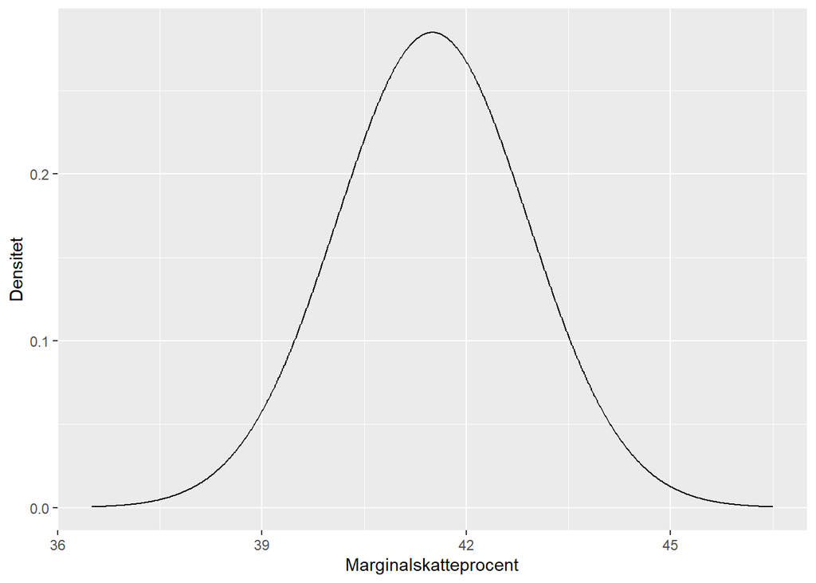

```r
data_mean = 41.5
data_sd = 1.4

ggplot(data.frame(x = c(data_mean - 5, data_mean + 5)), aes(x)) +
  stat_function(fun = dnorm, n = 1000, args = list(mean = data_mean, sd = data_sd)) +
  labs(x = "Marginalskatteprocent", y = "Densitet")
```

## Opgave 2

We could itegrate the density function, but that seems like a lot of work..

```r
?pnorm
```

```
## starting httpd help server ... done
```

```r
## calculate probability
# lower.tail = TRUE -> P[X > x] meaning we start form left
pnorm(q = 38.7, sd = data_sd, mean = data_mean, lower.tail = TRUE)
```

```
## [1] 0.02275013
```

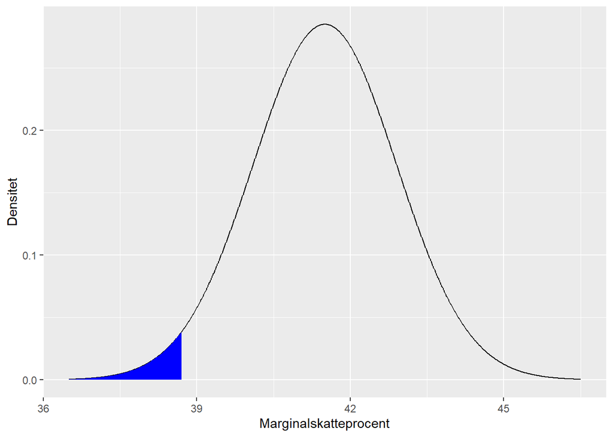

```r
## Plot
ggplot(data.frame(x = c(data_mean - 5, data_mean + 5)), aes(x)) +
  stat_function(fun = dnorm, n = 1000, args = list(mean = data_mean, sd = data_sd)) +
  # Coloring
  stat_function(fun = dnorm, args = list(mean = data_mean, sd = data_sd),
                xlim = c(max(data_mean - 5), 38.7), # Defines the interval
                geom = "area", fill = "blue") +
  labs(x = "Marginalskatteprocent", y = "Densitet")
```

## Opgave 3

```r
?pnorm
# Lowe.tail = False -> P[X \leq x] # Sampeling a point greater than some value
pnorm(q = 42, sd = data_sd, mean = data_mean, lower.tail = FALSE)
```

```
## [1] 0.3604924
```

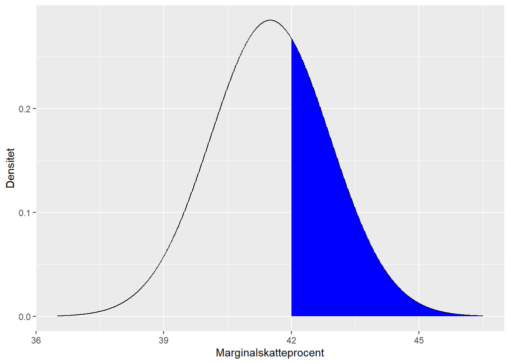

```r
ggplot(data.frame(x = c(data_mean - 5, data_mean + 5)), aes(x)) +
  stat_function(fun = dnorm, n = 1000, args = list(mean = data_mean, sd = data_sd)) +
  # Coloring
  stat_function(fun = dnorm, args = list(mean = data_mean, sd = data_sd),
                xlim = c(42, max(data_mean + 5)), # Defines the interval
                geom = "area", fill = "blue") +
  labs(x = "Marginalskatteprocent", y = "Densitet")
```

## Opgave 4

Bestem sandsynligheden for at en tilfældig person fra den givne population har en mar- ginalskatteprocent der er mellem 40% og 42.2%. Illustrer sandsynligheden p ̊a din skitse fra spørgsm ̊al 1 (eller lav en ny skitse).

Hvis finder afstanden mellem sandsyligheden for at den er over 42.2 til sandsyligheden for at den ligger over 40, så burde vi få intervallet.

P[X < 42.2] - P[X < 40]

```r
p_1 <- pnorm(q = c(42.2), sd = data_sd, mean = data_mean, lower.tail = TRUE) # Mindre end 42
p_2 <- pnorm(q = c(40), sd = data_sd, mean = data_mean, lower.tail = TRUE) # Større end 40
p_1 - p_2
```

```
## [1] 0.5494741
```

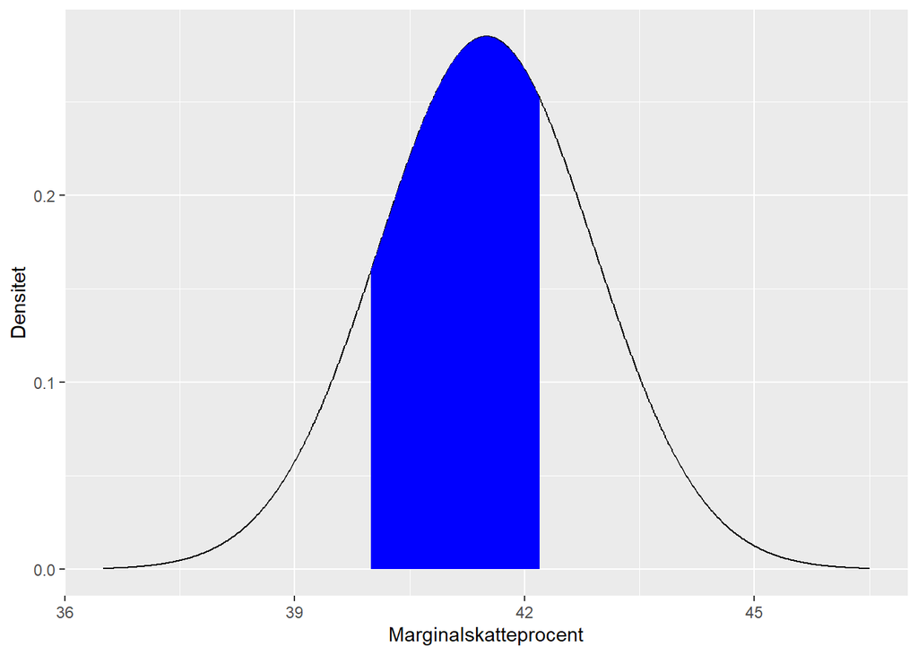

```r
ggplot(data.frame(x = c(data_mean - 5, data_mean + 5)), aes(x)) +
  stat_function(fun = dnorm, n = 1000, args = list(mean = data_mean, sd = data_sd)) +
  # Coloring
  stat_function(fun = dnorm, args = list(mean = data_mean, sd = data_sd),
                xlim = c(40, 42.2), # Defines the interval
                geom = "area", fill = "blue") +
  labs(x = "Marginalskatteprocent", y = "Densitet")
```

## Opgave 5

Betragt 10 personer fra populationen og antag at deres marginalskatteprocenter er uaf- hængige af hinanden (jordbrugsøkonomerne kan overveje hvorn ̊ar dette er en rimelig antagelse). Angiv fordelingen af gennemsnittet af de ti personers marginalskatteprocent. Vink: Du kan bruge Infobox 4.3. Bestem derefter sandsynligheden for at gennemsnittet for de ti personer er mindre end 42%. Sammenlign med sandsynligheden fra spørgsm ̊al 3, og forklar forskellen.

Det virker til at vi skal opdele de 1000 mennesker i grupper af 10, hvorefter vi beregner gennemsnits værdien for hver.

```r
set.seed(42) # Universe, life and everything

# Create data
my_data <- matrix(nrow = 100, ncol = 10, data = rnorm(1000, mean = data_mean, sd = data_sd))
x <- rowMeans(my_data) # Calculate means, makes the matrix into a vector
length(x)
```

```
## [1] 100
```

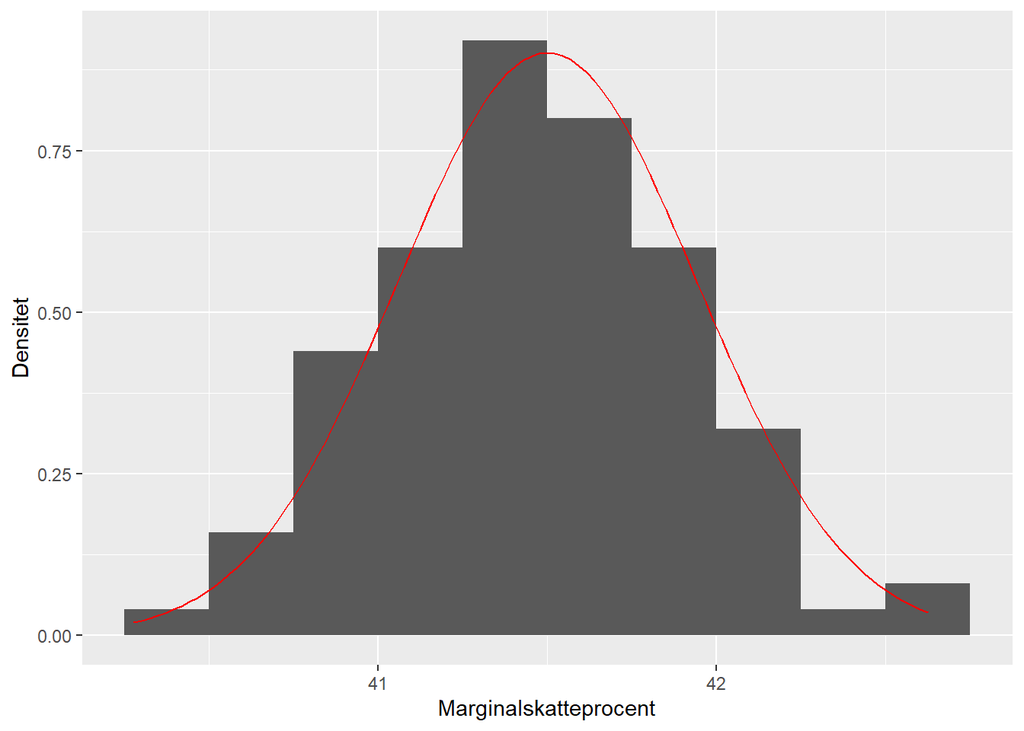

```r
# Defines the red function
f <- function(x) dnorm(x, mean = data_mean, sd = data_sd/sqrt(10))


ggplot(data.frame(x = x), aes(x)) +
  geom_histogram(boundary = 0, # Start postition of bar
                 binwidth = 0.25,
                 aes(y= ..density.. ) # Turn into probabilities, equivalent to prob = TRUE
  ) +
  stat_function(fun = f, color = "red") +
  labs(x = "Marginalskatteprocent", y = "Densitet")
```

```r
dnorm(x, mean = data_mean, sd = data_sd/sqrt(10))
```

[output not shown]